# Übung 1

Parameter einer Binomialverteilung.

true  
2021-03-04

# Schätzen des Parameters $\theta$ einer Binomialverteilung

Sie verabreichen einen Test, der aus 10 Fragen besteht. Die Fragen sind etwa gleich schwierig, und Sie sind sich sicher, dass die Fragen weder zu leicht noch zu schwierig für Ihre Schüler sind. Beim Betrachten der Resultate fällt Ihnen das Ergebnis eines Schülers besonders auf.

Bisher hatten Sie 4 solcher Tests verabreicht. Dieser Schüler schneidet normalerweise unterdurchschnittlich ab, mit Ergebnissen von $4/10$, $3/10$, $2/10$ und $4/10$ richtigen Antworten. Sie haben sich schon vorgenommen, die Elter des Schülers zu kontaktieren, da Sie sich Sorgen machen.

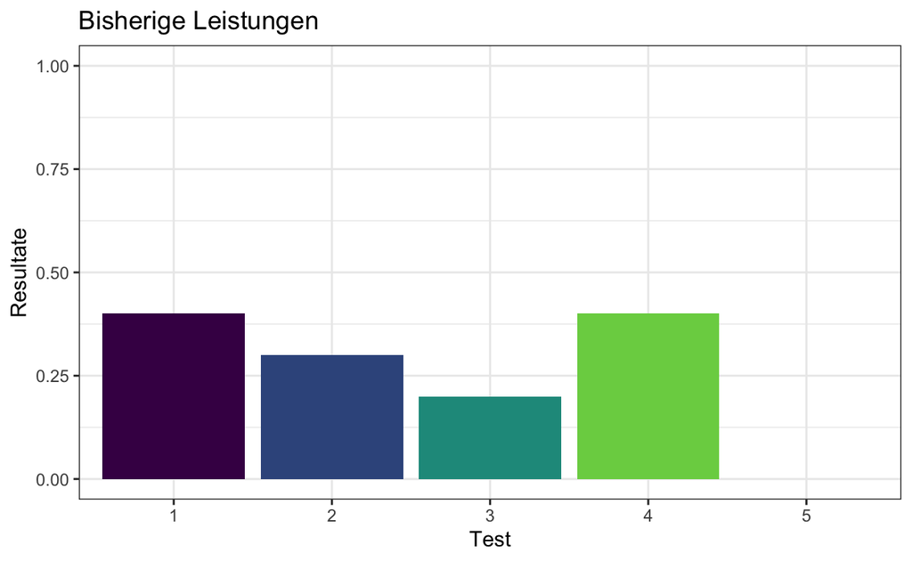

```r
tibble(Test = as_factor(1:5), Resultate = c(4/10, 3/10, 2/10, 4/10, NA)) %>%
  ggplot(aes(Test, Resultate, fill = Test)) +
  geom_bar(stat = 'identity') +
  scale_fill_viridis_d(end = 0.8) +
  scale_y_continuous(limits = c(0, 1)) +
  theme_bw() +
  theme(legend.position = "none") +
  ggtitle("Bisherige Leistungen")
```

Bei diesem Test sehen die Antworten aber so aus:

```r
answers <- c(1, 1, 1, 1, 0, 1, 1, 1, 1, 1)
```

`1` bedeutet, die Frage wurde richtig beantwortet, `0` steht für eine inkorrekte Antwort.

Berechnen Sie die Anzahl korrekter Antworten, sowie die Anzahl korrekter Antworten in den bisherigen Tests.

```r
ncorrect <- sum(answers)
nquestions <- length(answers)
prior_ncorrect <- 4 + 3 + 2 +4
prior_nquestions <- 4 * 10
prior_nwrong <- prior_nquestions - prior_ncorrect
```

Sie freuen sich—vielleicht hat sich der Schüler bei diesem Test besonders Mühe gegeben. Sie überlegen sich, ob Sie nun warten sollen, oder doch mit den Eltern einen Termin für ein Gespräch abmachen sollen.

Vielleicht kann Ihnen Bayesianische Inferenz helfen?

Versuchen Sie, mit Hilfe Ihres Vorwissens über die Leistungen des Schülers seine Fähigkeit (ability), Fragen richtig zu beantworten, zu schätzen. Da Sie wissen, dass Sie die Fähigkeit nur ungenau schätzen können, wollen Sie Ihre Unsicherheit mit einer Posterior Distribution quantifizieren.

Der R Code, den Sie bei dieser Übung brauchen, ist schon gegeben. Sie brauchen lediglich die Lücken auszufüllen.

Z.B.

```r
ncorrect <- sum(___)
```

wird zu

```r
ncorrect <- sum(answers)
```

Definieren sie zuerst einen Vektor, der alle möglichen Werte des Parameters $\theta$ enthält.

```r
n_points <- 100
theta_grid <- seq(from = 0 , to = 1 , length.out = n_points)
```

Berechnen Sie nun die Wahrscheinlichkeit, das Testergebnis des Schülers zu erreichen, d.h. die Wahrscheinlichkeit der Daten für jeden möglichen Parameterwert.

```r
likelihood <- dbinom(x = ___ , size = ___ , prob = theta_grid)
```

Sie können diese Wahrscheinlichkeit so graphisch darstellen.

```r
tibble(theta_grid, likelihood) %>%
  ggplot(aes(x = theta_grid, y = likelihood)) +
  geom_line()
```

## Aufgabe 1

Wenn Sie kein Vorwissen hätten: Was würden Sie als Schätzung der Fähigkeit des Schülers benutzen?

## Aufgabe 2

Versuchen Sie nun, Ihr Vorwissen über die Leistungen des Schülers in Form einer Prior-Verteilung auszudrücken.

Versuchen Sie es mit einer Beta-Verteilung. Schauen Sie im [Skript](https://kogpsy.github.io/neuroscicomplab/01-intro-bayesian-stats.html#beta-verteilung) nach.

```r
prior <- dbeta(x = theta_grid, shape1 = ___,  shape2 = ___)
```

## Aufgabe 3

Berechnen Sie die Posterior-Verteilung als Produkt von Likelihood und Ihrem Prior.

```r
unstandardized_posterior <- likelihood * prior

posterior <- unstandardized_posterior / sum(unstandardized_posterior)

posterior
```

## Plot

Stellen Sie Prior, Likelihood und Posterior grafisch dar

```r
df <- tibble(theta_grid, prior, likelihood, posterior)

df %>%
  pivot_longer(-theta_grid, names_to = "distribution", values_to = "density") %>%
  mutate(distribution = as_factor(distribution)) %>%
  ggplot(aes(theta_grid, density, color = distribution)) +
  geom_line(size = 1.5) +
  geom_vline(xintercept = 9/10, linetype = "dashed") +
  scale_color_viridis_d(end = 0.8) +
  xlab("Theta Werte") +
  ylab("") +
  facet_wrap(~distribution, scales = "free_y") +
  theme_bw()
```

## Aufgabe 4

Was ist die Warscheinlichkeit, dass jemand mit solchen Vorleistungen mindestens 9 Fragen von 10 beantwortet, falls die Vorleistungen tatsächlich die wahre Fähigkeiten der Schüler messen?